# Introduction to ggplot2

## 3.5 `aes`

`aes` will be one of the functions that you will most use. The function connects data with what we see on the graph. We refer to this connection as the **aesthetic mappings**. The outcome of this function is often used as the argument of a geometry function. This example produces a scatter plot of total murders versus population in millions:

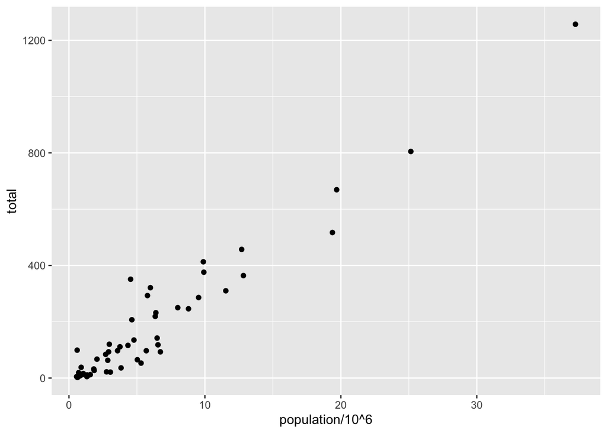

```r
murders %>%
  ggplot() +
  geom_point(aes(x = population/10^6, y = total))   # Map population to x, total to y
```

### 3.5.1 Adding other layers

Because each state (each point) has a label we need an aesthetic mapping to make the connection. By reading the help file we learn that we supply the mapping between point and label through the `label` argument of `aes`. So the code looks like this:

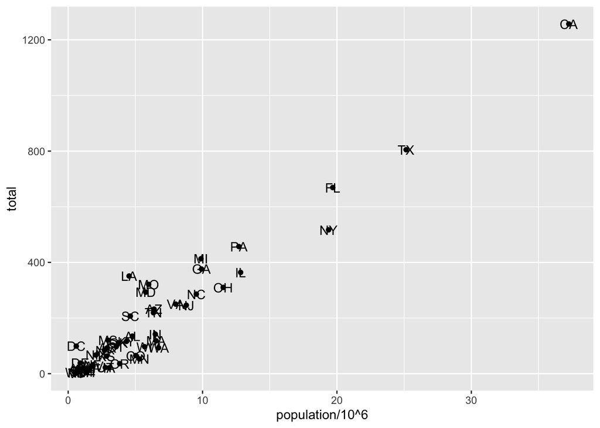

```r
murders %>%
  ggplot() +
  geom_point(aes(population/10^6, total)) +
  geom_text(aes(population/10^6, total, label = abb))   # NEW: add a text label per point
```

### 3.5.2 Tinkering with other arguments

Note that each geometry function has many arguments other than `aes` and `data`. They tend to be specific to the function. For example, in the plot we wish to make, the points are larger than the default ones. In the help file we see that `size` is an aesthetic and we can change it like this:

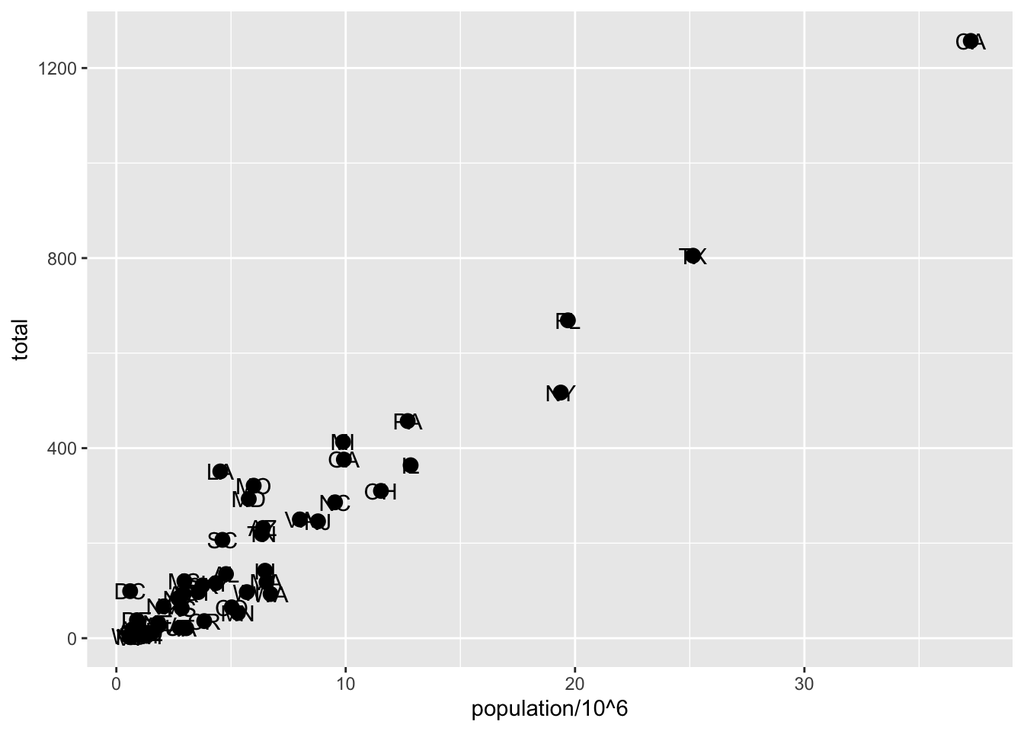

```r
murders %>%
  ggplot() +
  geom_point(aes(population/10^6, total), size = 3) +   # NEW: bigger points (size = 3)
  geom_text(aes(population/10^6, total, label = abb))
```

Note that `size` is **not** a mapping, it affects all the points so we do not need to include it inside `aes`.

Now that the points are larger, it is hard to see the labels. If we read the help file for `geom_text` we learn of the `nudge_x` argument which moves the text slightly to the right:

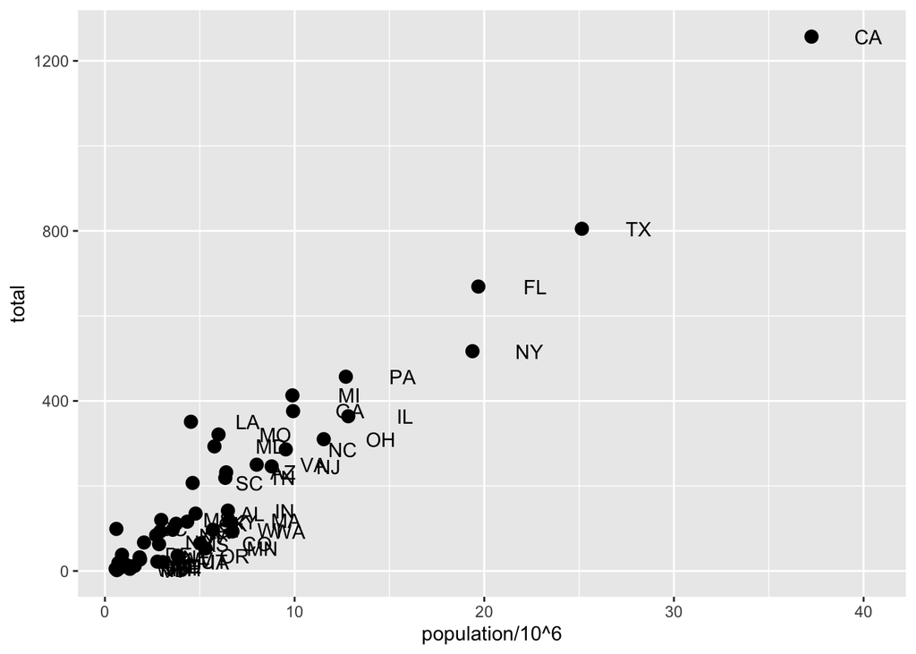

```r
murders %>%
  ggplot() +
  geom_point(aes(population/10^6, total), size = 3) +
  geom_text(aes(population/10^6, total, label = abb), nudge_x = 3)   # NEW: shift labels right
```

This is preferred as it makes it easier to read the text.

## 3.6 Global aesthetic mappings

Note that in the previous line of code, we define the mapping `aes(population/10^6, total)` twice, once in each geometry. We can avoid this by using a *global* aesthetic mapping. We can do this when we define the blank slate `ggplot` object.

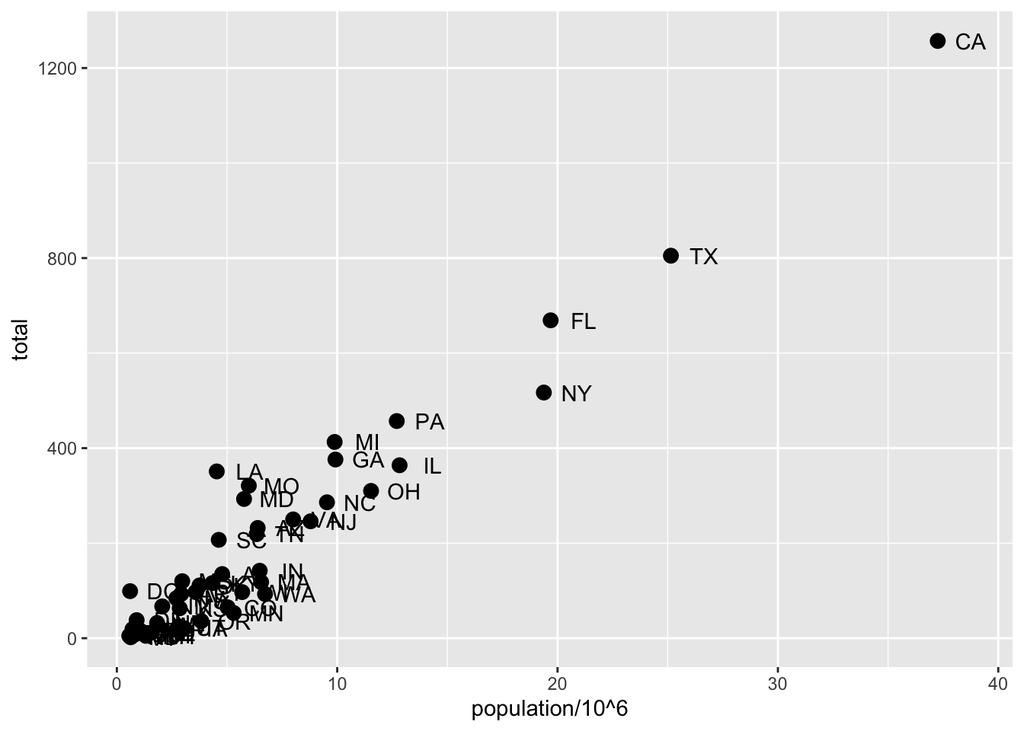

```r
murders %>%
  ggplot(aes(x = population/10^6, y = total, label = abb)) +   # Define mappings ONCE, globally
  geom_point(size = 3) +
  geom_text(nudge_x = 1.5)
```

We keep the `size` and `nudge_x` argument in `geom_point` and `geom_text` respectively because we only want to increase the size of points and nudge only the labels. Also note that the `geom_point` function does not need a `label` argument and therefore ignores it.

### 3.6.1 Local aesthetic mappings override global ones

If we need to, we can override the global mapping by defining a new mapping within each layer. These *local* definitions override the *global*. Here is an example:

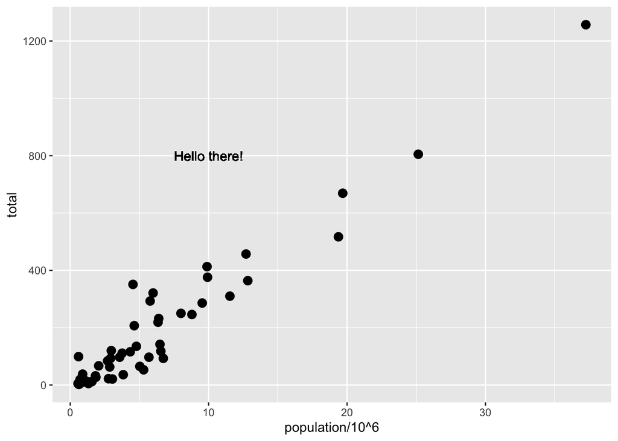

```r
murders %>%
  ggplot(aes(x = population/10^6, y = total, label = abb)) +
  geom_point(size = 3) +
  geom_text(aes(x = 10, y = 800, label = "Hello there!"))   # Local mapping overrides the global one
```

Clearly, the second call to `geom_text` does not use `population` and `total` on the `x` and `y` axis.

## 3.7 Scales

Recall that our desired scales are in log-scale. This is not the default so this change needs to be added through a *scales* layer. A quick look at the cheat sheet reveals `scale_x_continuous` is needed to edit the behavior of scales. We use it like this:

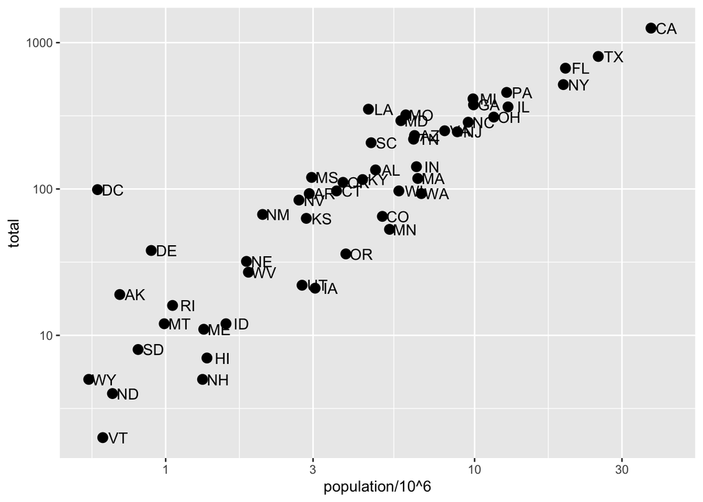

```r
murders %>%
  ggplot(aes(x = population/10^6, y = total, label = abb)) +
  geom_point(size = 3) +
  geom_text(nudge_x = 0.05) +
  scale_x_continuous(trans = "log10") +   # NEW: log-transform the x-axis
  scale_y_continuous(trans = "log10")     # NEW: log-transform the y-axis
```

Because we are in the log-scale now, the *nudge* must be made smaller.

This particular transformation is so common that `ggplot` provides specialized functions:

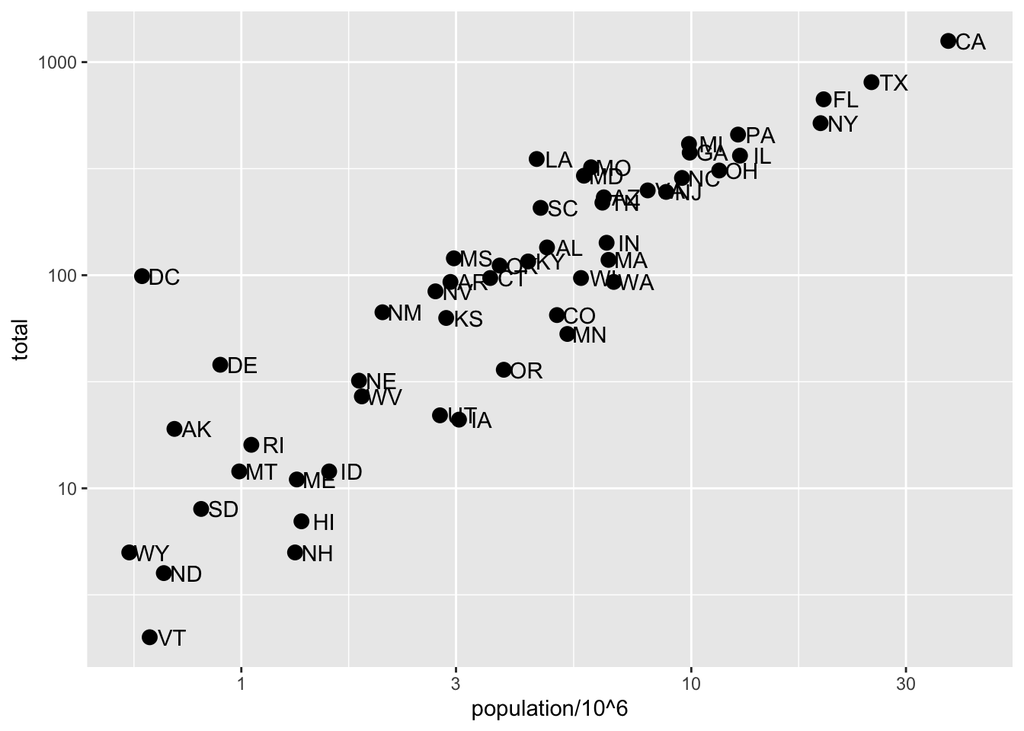

```r
murders %>%
  ggplot(aes(x = population/10^6, y = total, label = abb)) +
  geom_point(size = 3) +
  geom_text(nudge_x = 0.05) +
  scale_x_log10() +   # Shorthand for scale_x_continuous(trans = "log10")
  scale_y_log10()
```

## 3.8 Labels and Titles

Similarly, the cheat sheet quickly reveals that to change labels and add a title we use the following functions: `xlab`, `ylab` and `ggtitle`.

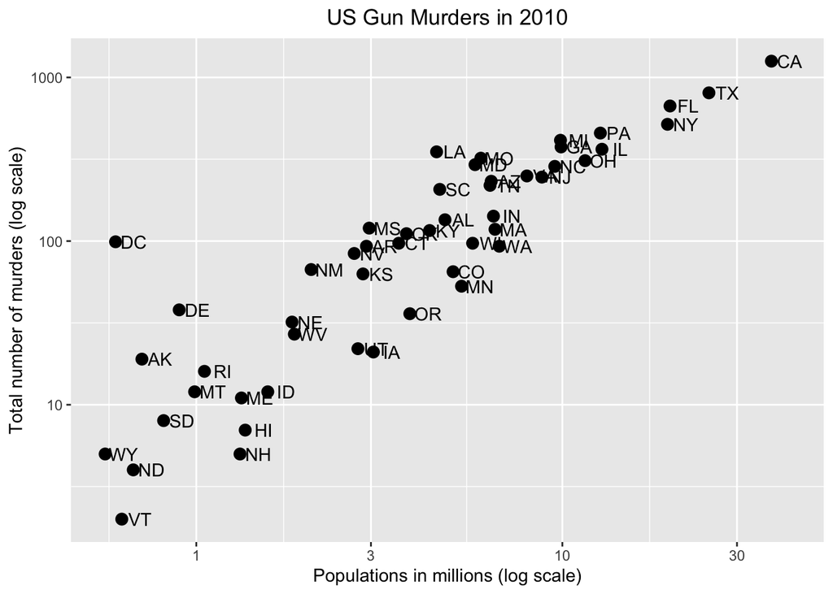

```r
murders %>%
  ggplot(aes(x = population/10^6, y = total, label = abb)) +
  geom_point(size = 3) +
  geom_text(nudge_x = 0.05) +
  scale_x_log10() +
  scale_y_log10() +
  xlab("Populations in millions (log scale)") +           # NEW: x-axis label
  ylab("Total number of murders (log scale)") +           # NEW: y-axis label
  ggtitle("US Gun Murders in 2010") +                     # NEW: title
  theme(plot.title = element_text(hjust = 0.5))           # Center the title
```

We are almost there! All we have to do is add color, a legend and optional changes to the style.

# 4 Fine-tuning visualizations

## 4.1 Categories as colors

Note that we can change the color of the points using the `color` argument in the `geom_point` function.

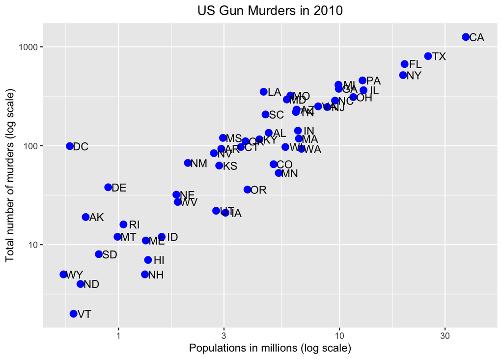

```r
murders %>%
  ggplot(aes(x = population/10^6, y = total, label = abb)) +
  geom_point(size = 3, color = "blue") +   # color OUTSIDE aes(): every point the same blue
  geom_text(nudge_x = 0.05) +
  scale_x_log10() +
  scale_y_log10() +
  xlab("Populations in millions (log scale)") +
  ylab("Total number of murders (log scale)") +
  ggtitle("US Gun Murders in 2010") +
  theme(plot.title = element_text(hjust = 0.5))
```

This, of course, is not what we want. We want to assign color depending on the geographical region. A nice default behavior of `ggplot2` is that if we assign a categorical variable to color, it automatically assigns a different color to each category. It also adds a legend!

To map each point to a color, we need to use `aes` since this is a mapping. So we use the following code:

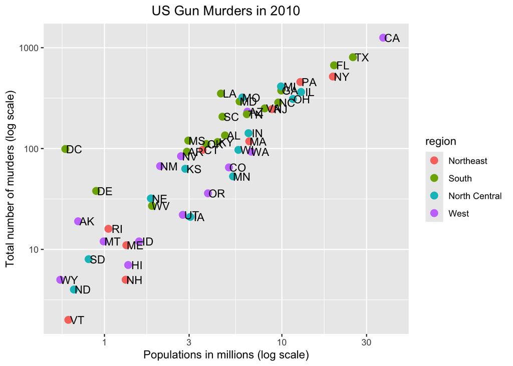

```r
murders %>%
  ggplot(aes(x = population/10^6, y = total, label = abb)) +
  geom_point(aes(color = region), size = 3) +   # color INSIDE aes(): mapped to region + legend
  geom_text(nudge_x = 0.05) +
  scale_x_log10() +
  scale_y_log10() +
  xlab("Populations in millions (log scale)") +
  ylab("Total number of murders (log scale)") +
  ggtitle("US Gun Murders in 2010") +
  theme(plot.title = element_text(hjust = 0.5))
```

Here we see yet another useful default behavior: `ggplot2` has automatically added a legend that maps color to region.

Key idea: inside vs. outside `aes()` Put a setting **inside** `aes()` to *map it to a variable* (each value gets its own color/size, and a legend appears). Put it **outside** `aes()` to set one fixed value for *every* point. “All points blue” goes outside; “color by region” goes inside.

## 4.2 Adding a line

We want to add a line that represents the average murder rate for the entire country. Note that once we determine the per million rate to be $r$, this line is defined by the formula: $y = r x$ with $y$ and $x$ our axes: total murders and population in millions respectively. In the log-scale this line turns into: $\log(y) = \log(r) + \log(x)$. So in our plot it’s a line with slope 1 and intercept $\log(r)$. To compute this value we use our `dplyr` skills:

```r
# National murder rate per MILLION people (a single number).
r <- murders %>%
     summarize(murder_rate = sum(total) / sum(population) * 10^6) %>% .$murder_rate
r
```

```
#> [1] 30.34555
```

To add a line we use the `geom_abline` function. `ggplot` uses `ab` in the name to remind us we are supplying the intercept (`a`) and slope (`b`). The default line has slope 1 and intercept 0 so we only have to define the intercept:`intercept = log10(r)`. We can change the line type and color of the lines using arguments. We also draw it first so it doesn’t go over our points.

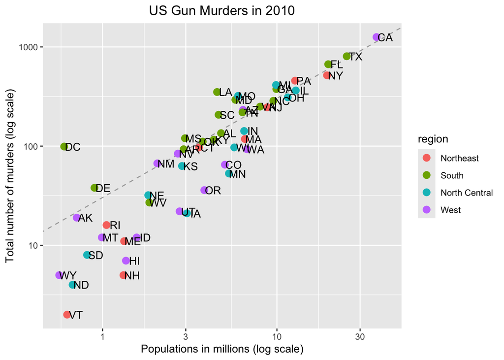

```r
murders %>%
  ggplot(aes(x = population/10^6, y = total, label = abb)) +
  geom_abline(intercept = log10(r), lty = 2, color = "darkgrey") +   # NEW: US-average line, drawn first
  geom_point(aes(color = region), size = 3) +
  geom_text(nudge_x = 0.05) +
  scale_x_log10() +
  scale_y_log10() +
  xlab("Populations in millions (log scale)") +
  ylab("Total number of murders (log scale)") +
  ggtitle("US Gun Murders in 2010") +
  theme(plot.title = element_text(hjust = 0.5))
```

## 4.3 Other adjustments

The default plots created by `ggplot` are already very useful. But often, we need to make minor tweaks to the default behavior. Although it is not always obvious how to make these even with the cheat sheet, `ggplot2` is very flexible.

For example, note that we can make changes to the legend via the `scale_color_discrete` function. For example, in our plot the word *region* is not capitalized. We can change that like this:

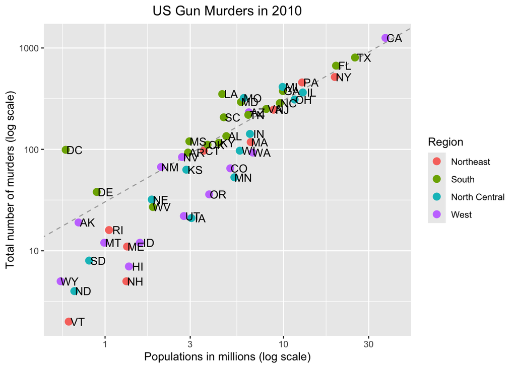

```r
murders %>%
  ggplot(aes(x = population/10^6, y = total, label = abb)) +
  geom_abline(intercept = log10(r), lty = 2, color = "darkgrey") +
  geom_point(aes(color = region), size = 3) +
  geom_text(nudge_x = 0.05) +
  scale_x_log10() +
  scale_y_log10() +
  xlab("Populations in millions (log scale)") +
  ylab("Total number of murders (log scale)") +
  ggtitle("US Gun Murders in 2010") +
  theme(plot.title = element_text(hjust = 0.5)) +
  scale_color_discrete(name = "Region")   # NEW: capitalize the legend title
```

## 4.4 Add-on packages

The power of `ggplot2` is augmented further due to the availability of add-on packages. The remaining changes required to put the finishing touches on our plot require the `ggthemes` and `ggrepel` packages.

The style of a `ggplot` graph can be changed using the `theme` functions. Several themes are included as part of the `ggplot2` package. In fact, for most of the plots in this course we use a function in the `dslabs` package that automatically sets a default theme:

```r
ds_theme_set()   # Set the dslabs default theme
```

Many other themes are added by the package `ggthemes`. Among those are the `theme_economist` theme that we will use here. After loading the package, you can change the style of the plot by adding the layer `theme_economist()`.

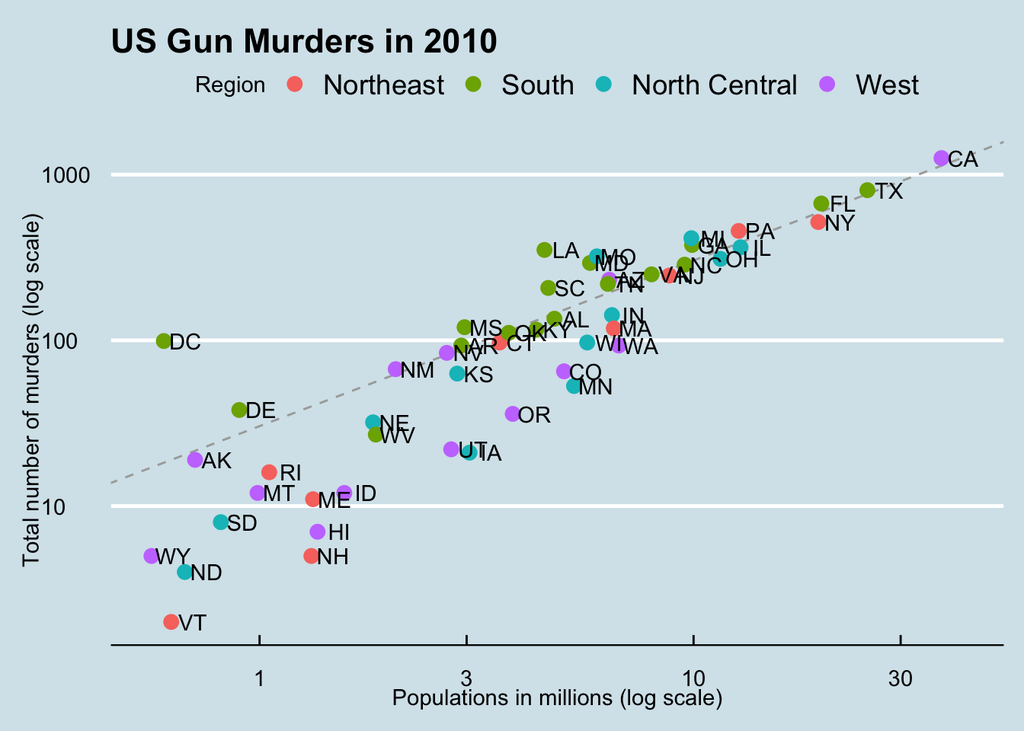

```r
murders %>%
  ggplot(aes(x = population/10^6, y = total, label = abb)) +
  geom_abline(intercept = log10(r), lty = 2, color = "darkgrey") +
  geom_point(aes(color = region), size = 3) +
  geom_text(nudge_x = 0.05) +
  scale_x_log10() +
  scale_y_log10() +
  xlab("Populations in millions (log scale)") +
  ylab("Total number of murders (log scale)") +
  ggtitle("US Gun Murders in 2010") +
  theme(plot.title = element_text(hjust = 0.5)) +
  scale_color_discrete(name = "Region") +
  theme_economist()   # NEW: apply the Economist style
```

You can see how some of the other themes look like by simply changing the function. For example you might try the `theme_fivethirtyeight()` theme instead.

The final difference has to do with the position of the labels. Note that in our plot, some of the labels fall on top of each other. The add-on package `ggrepel` includes a geometry that adds labels ensuring that they don’t fall on top of each other. We simply change `geom_text` with `geom_text_repel`.

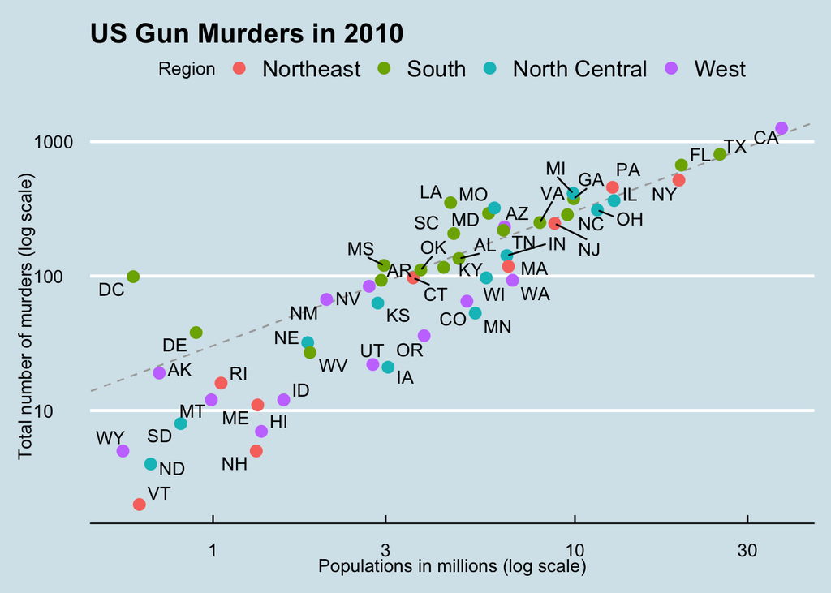

```r
murders %>%
  ggplot(aes(x = population/10^6, y = total, label = abb)) +
  geom_abline(intercept = log10(r), lty = 2, color = "darkgrey") +
  geom_point(aes(color = region), size = 3) +
  geom_text_repel() +   # NEW: labels that repel each other so they don't overlap
  scale_x_log10() +
  scale_y_log10() +
  xlab("Populations in millions (log scale)") +
  ylab("Total number of murders (log scale)") +
  ggtitle("US Gun Murders in 2010") +
  scale_color_discrete(name = "Region") +
  theme_economist()
```

## 4.5 Putting it all together

So now that we are done testing we can write one piece of code that produces our desired plot from scratch.

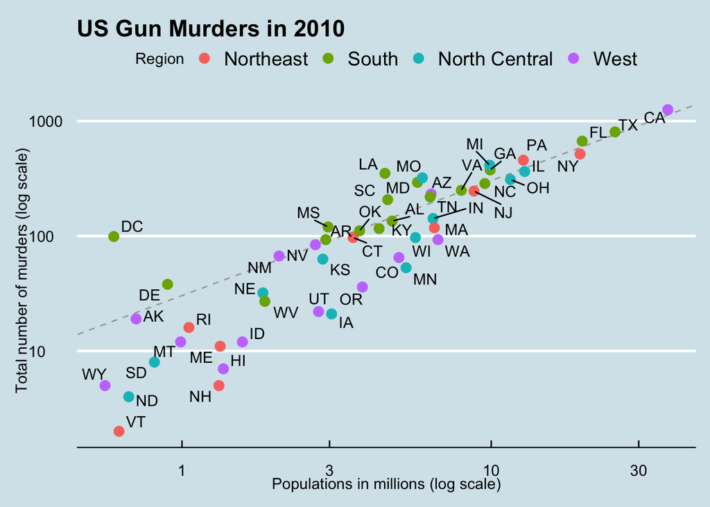

```r
library(tidyverse)
library(dslabs)
library(ggthemes)
library(ggrepel)

## Load the data
data(murders)

## First define the slope of the line
r <- murders %>%
     summarize(murder_rate = sum(total) / sum(population) * 10^6) %>% .$murder_rate

## Now make the plot
murders %>%
  ggplot(aes(x = population/10^6, y = total, label = abb)) +
  geom_abline(intercept = log10(r), lty = 2, color = "darkgrey") +
  geom_point(aes(color = region), size = 3) +
  geom_text_repel() +
  scale_x_log10() +
  scale_y_log10() +
  xlab("Populations in millions (log scale)") +
  ylab("Total number of murders (log scale)") +
  ggtitle("US Gun Murders in 2010") +
  scale_color_discrete(name = "Region") +
  theme_economist()
```

# 5 Visualization principles

We’ve focused on *how* to build plots. This section is about building *good* ones. The examples below contrast common but misleading chart choices with clearer alternatives. The guiding question is always: does the chart let the reader read the data accurately and quickly?

```r
library(gridExtra)   # arrange several plots in one figure (grid.arrange)
```

## 5.1 Avoid pie and donut charts

Humans judge **length** and **position** far more accurately than **angles** and **areas**. Pie charts (and donut charts) ask the reader to compare angles, which is hard — try ranking the browsers below, or judging how much each changed from 2000 to 2015.

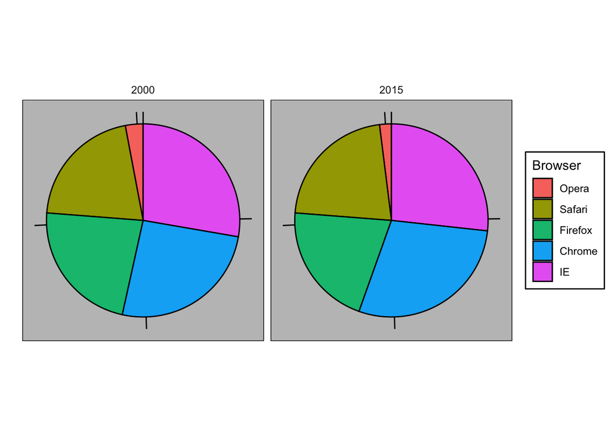

A donut chart is the same idea with the center removed — it discards even the (weak) area cue, leaving only arc length:

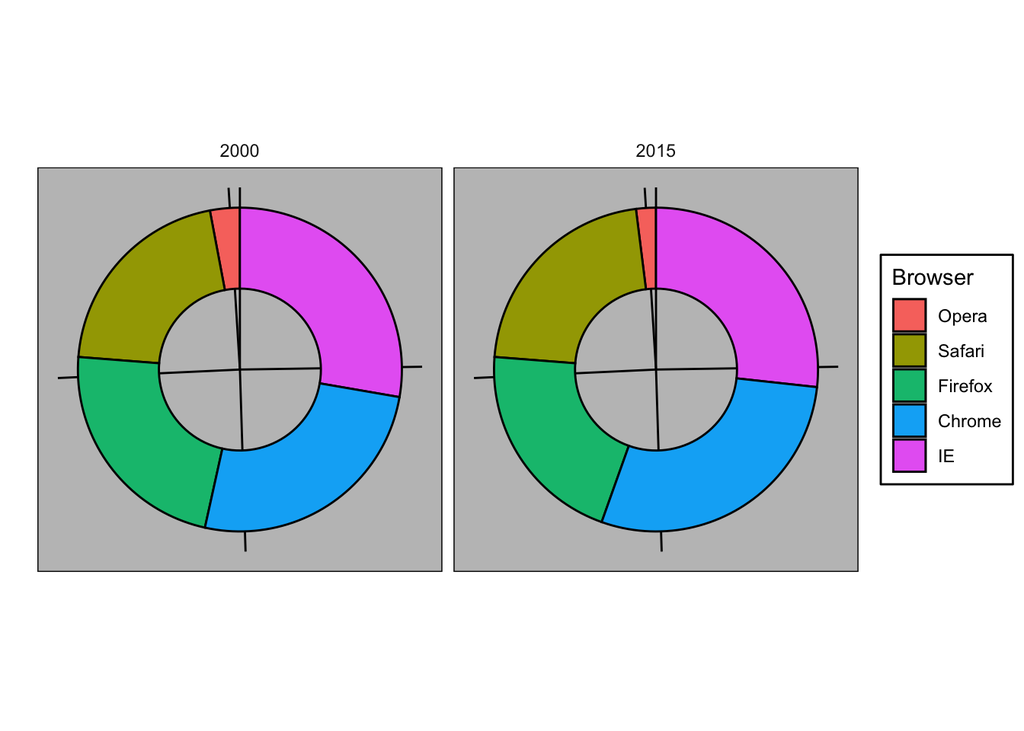

Often the honest thing is to just show the numbers:

| Browser | 2000 | 2015 |
| --- | --- | --- |
| Opera | 3 | 2 |
| Safari | 21 | 22 |
| Firefox | 23 | 21 |
| Chrome | 26 | 29 |
| IE | 28 | 27 |

A **bar chart** turns those same numbers into lengths along a common baseline, which the eye reads precisely and can rank at a glance:

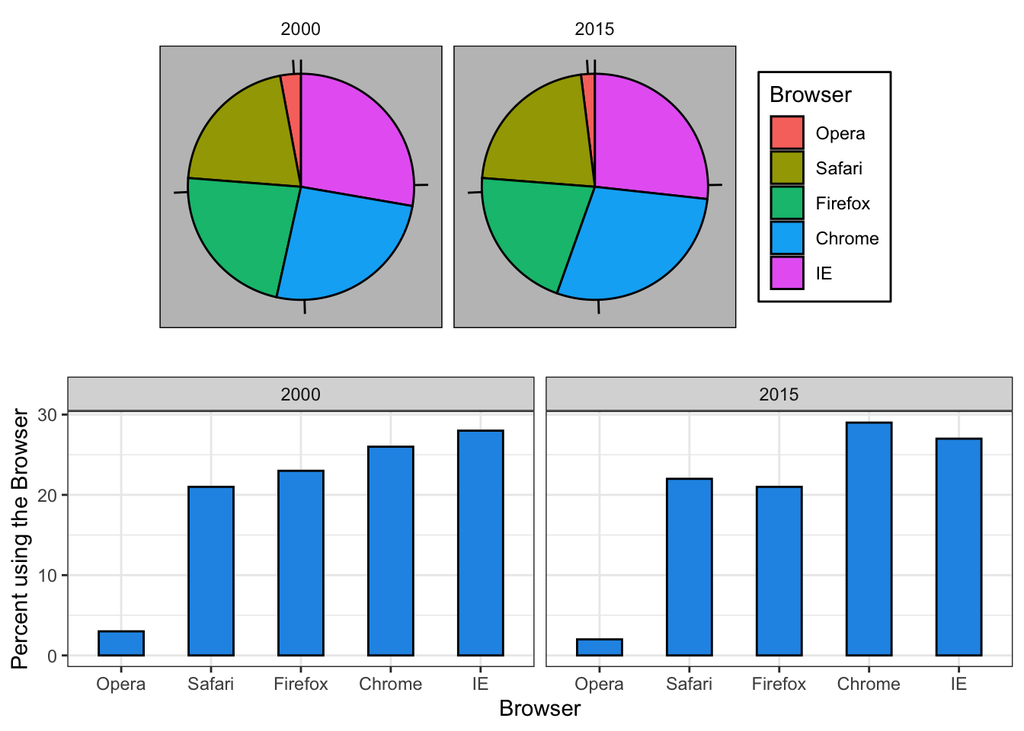

```r
# Bar chart of the same data: lengths on a shared axis are easy to compare and rank.
p2 <- browsers %>%
  ggplot(aes(Browser, Percentage)) +
  geom_bar(stat = "identity", width = 0.5, fill = 4, col = 1) +
  ylab("Percent using the Browser") +
  facet_grid(. ~ Year)
grid.arrange(p1, p2, nrow = 2)   # Pie (top) vs bar (bottom), side by side
```

Adding numeric labels to a pie helps a little, but if you need to print every number, the pie itself isn’t doing any work:

[figure not shown]

## 5.2 Start bars at zero

Because a bar encodes its value as a **length**, the axis must start at zero — otherwise the lengths no longer represent the numbers and small differences look huge. This border-apprehensions bar chart starts at zero, so the modest year-to-year change is shown honestly:

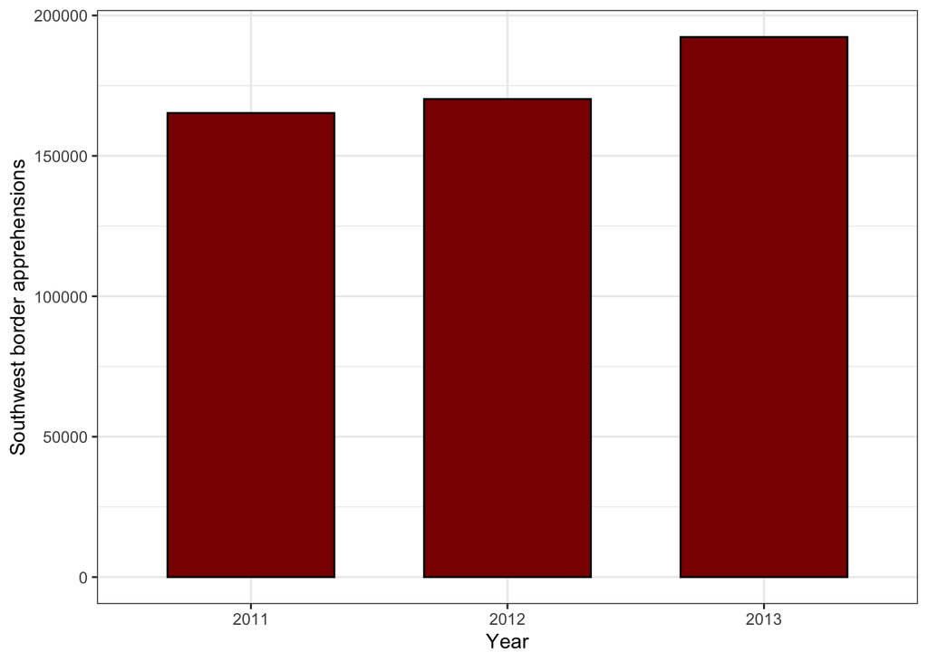

The same rule keeps election results honest — with a zero baseline, a near-tie *looks* like a near-tie:

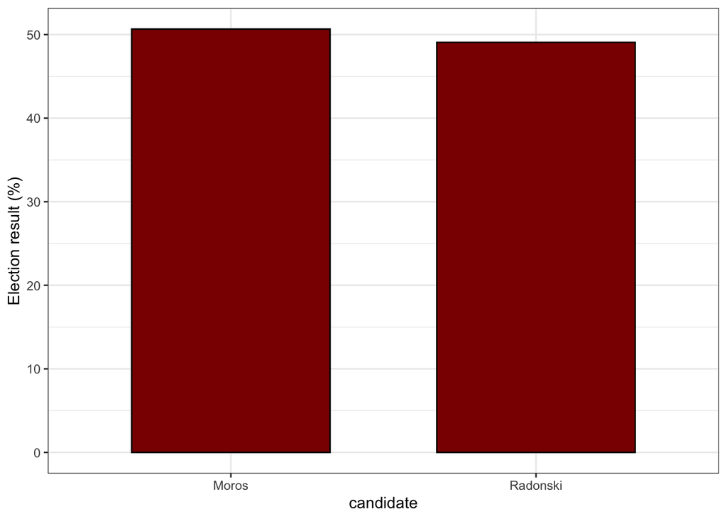

```r
data.frame(candidate = c("Moros", "Radonski"), percentages = c(50.66, 49.07)) %>%
  ggplot(aes(candidate, percentages)) +
  geom_bar(stat = "identity", fill = "darkred", col = "black", width = 0.65) +
  ylab("Election result (%)")
```

## 5.3 Represent quantities with length or position, not area

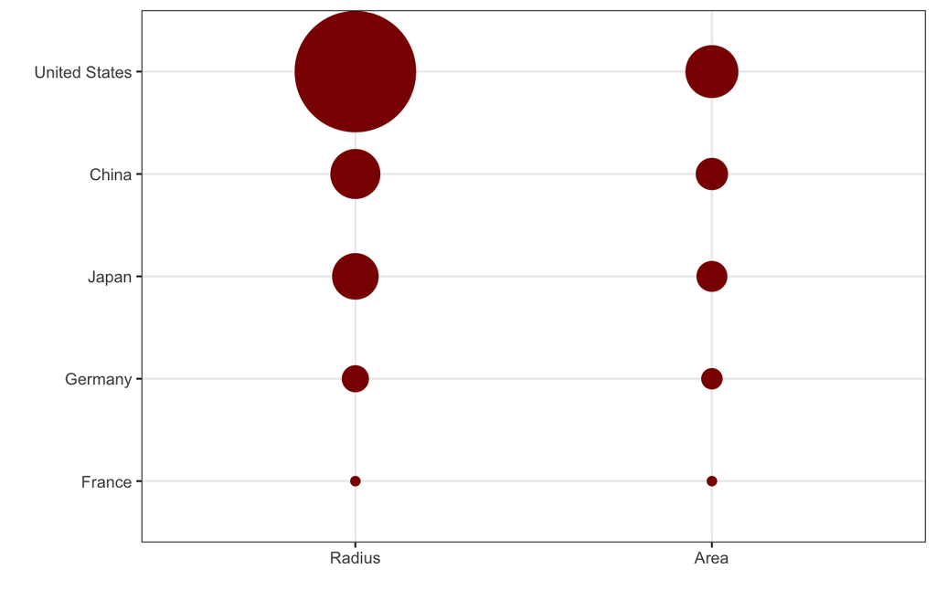

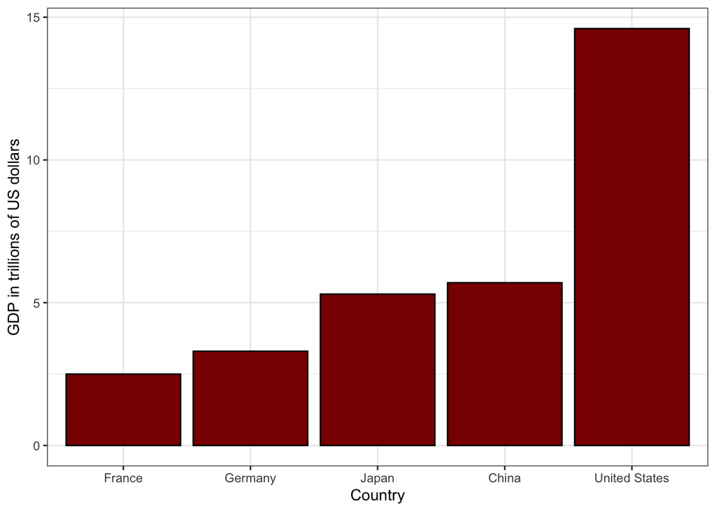

## 5.4 …but zero isn’t always required

The zero rule is about **bars**. When you encode values with **position** instead (points/dots), forcing the axis to zero can crush the very differences you want to show. Below, the left panel starts at zero and hides the variation across continents; the right panel lets the data set the range and the pattern is clear:

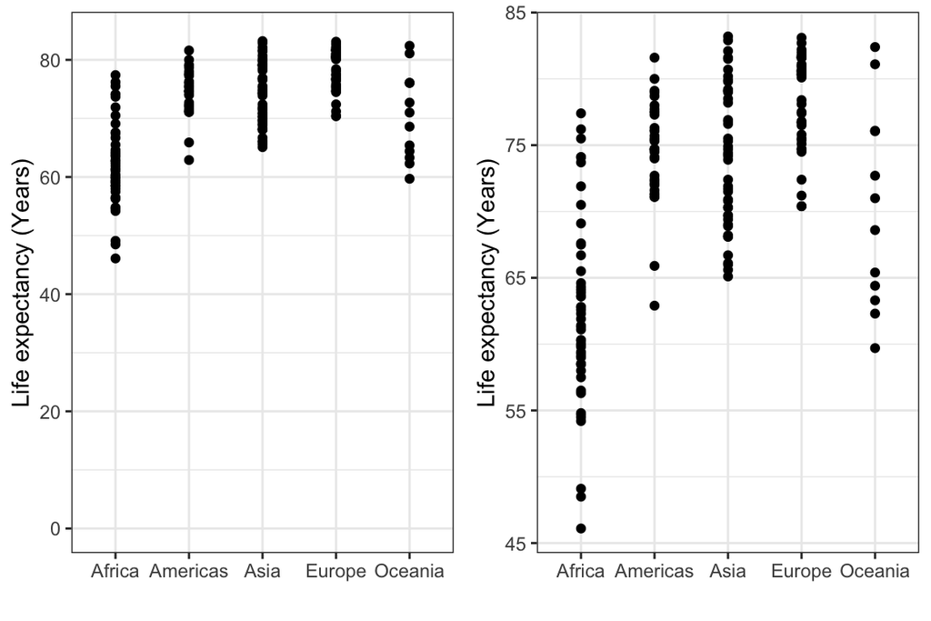

Principles, in one line Prefer **length and position** over angle and area; **start bars at zero** (but not necessarily dot/scatter plots); order categories meaningfully; and when in doubt, a clean table beats a confusing chart.

# 6 Case study: Vaccines

Vaccines are one of public health’s greatest successes, yet they’re often the target of doubt. A good visualization can make the case more powerfully than a table of numbers. We’ll create a powerful plot of measles in the United States.

```r
library(dslabs)
data(us_contagious_diseases)      # Yearly disease counts by U.S. state
head(us_contagious_diseases)
```

|  | disease | state | year | weeks_reporting | count | population |
| --- | --- | --- | --- | --- | --- | --- |
| 1 | Hepatitis A | Alabama | 1966 | 50 | 321 | 3345787 |
| 2 | Hepatitis A | Alabama | 1967 | 49 | 291 | 3364130 |
| 3 | Hepatitis A | Alabama | 1968 | 52 | 314 | 3386068 |
| 4 | Hepatitis A | Alabama | 1969 | 49 | 380 | 3412450 |
| 5 | Hepatitis A | Alabama | 1970 | 51 | 413 | 3444165 |
| 6 | Hepatitis A | Alabama | 1971 | 51 | 378 | 3481798 |

We compute a **rate** (cases per 100,000 people per year), adjusting for how many weeks each state actually reported, and drop Hawaii and Alaska (which became states partway through the record):

```r
measles <- us_contagious_diseases %>%
  filter(!state %in% c("Hawaii", "Alaska") & disease == "Measles") %>%   # Contiguous states, measles only
  mutate(rate = (count / weeks_reporting) * 52 / (population / 100000))   # Annualized rate per 100,000
```

`RColorBrewer` provides carefully designed color palettes. The **sequential** palettes suit data that runs low-to-high (like a rate); **diverging** palettes suit data with a meaningful midpoint.

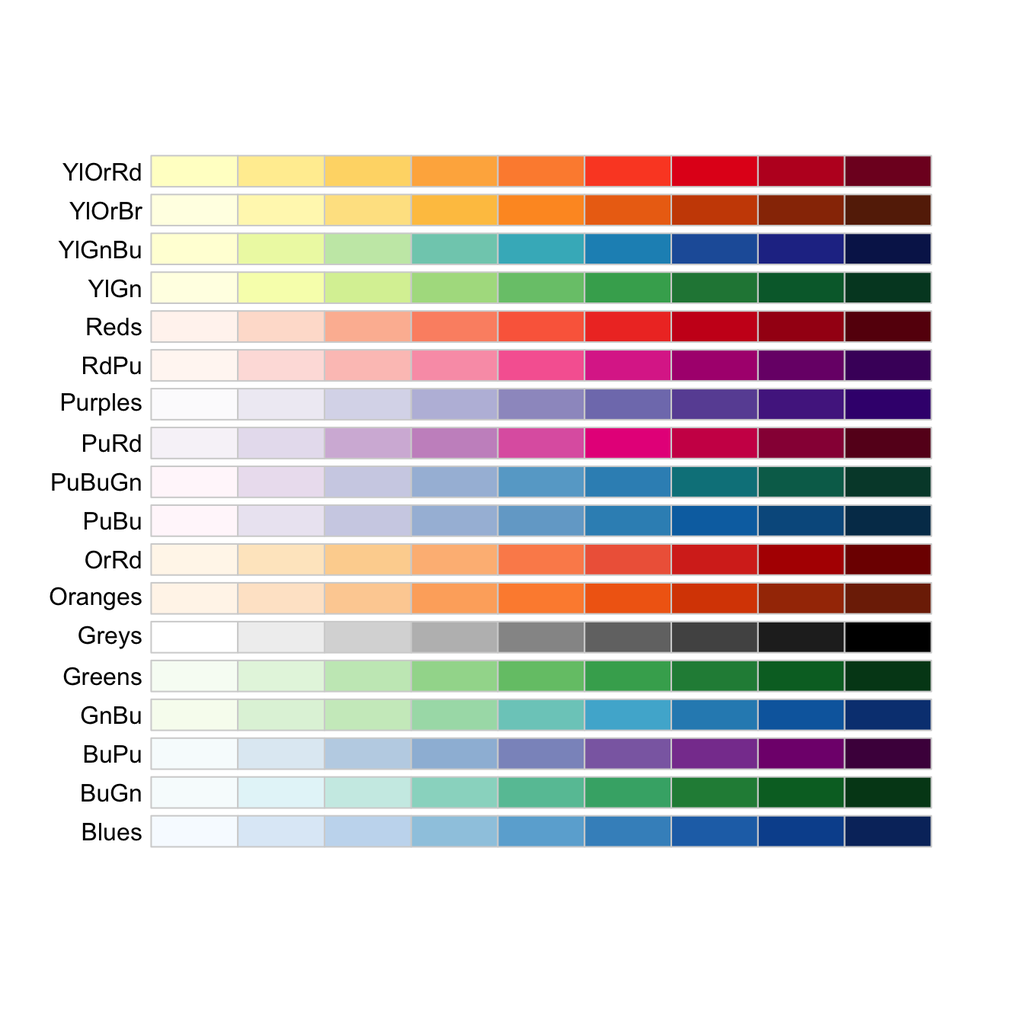

```r
library(RColorBrewer)
display.brewer.all(type = "seq")   # Sequential palettes (low -> high)
```

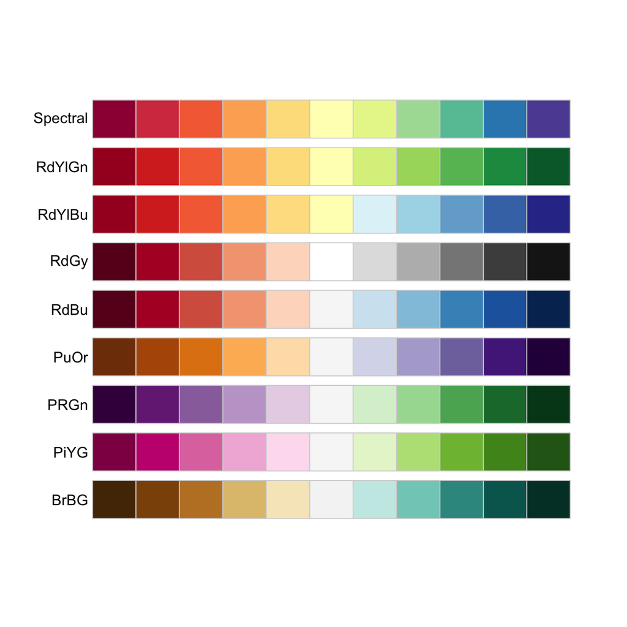

```r
display.brewer.all(type = "div")   # Diverging palettes (around a midpoint)
```

Now the plot: a **heatmap** (`geom_tile`) with year on the x-axis, states stacked on the y-axis, and color showing the measles rate. The blue vertical line marks 1963, when the vaccine was introduced.

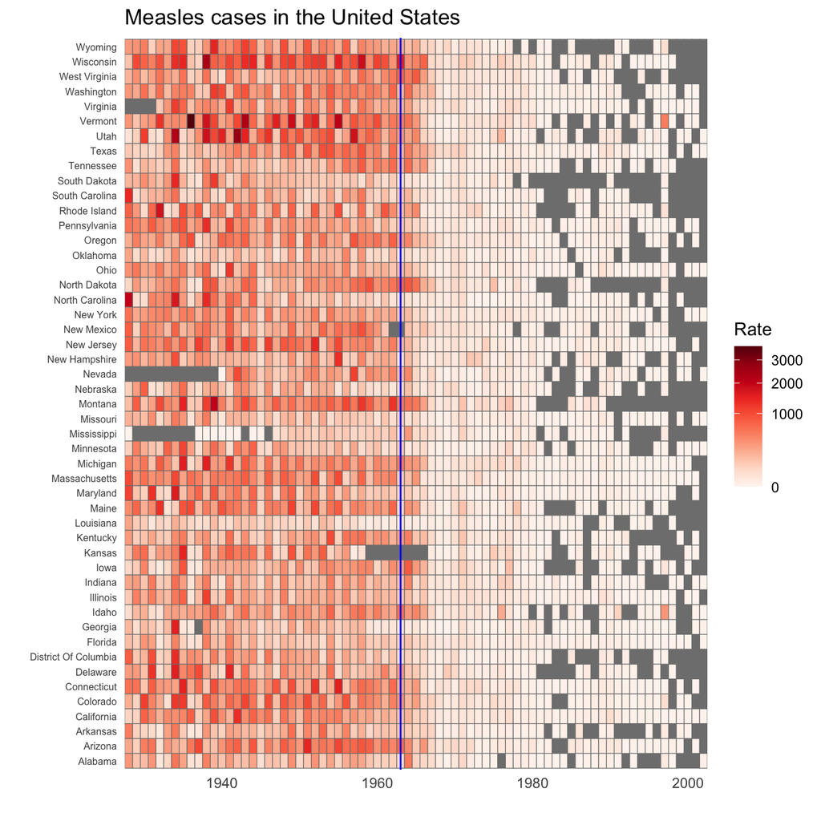

```r
measles %>%
  ggplot(aes(year, state, fill = rate)) +
  geom_tile(color = "grey50") +                                  # One colored tile per state-year
  scale_x_continuous(expand = c(0, 0)) +                         # No padding on the x-axis
  scale_fill_gradientn(colors = brewer.pal(9, "Reds"),           # Red = higher rate
                       trans = "sqrt",                           # Square-root scale reveals low values
                       name = "Rate") +
  geom_vline(xintercept = 1963, col = "blue") +                  # Vaccine introduced in 1963
  theme_minimal() +
  theme(panel.grid = element_blank(),
        axis.text.y = element_text(size = 6, lineheight = 0.8)) +
  ggtitle("Measles cases in the United States") +
  ylab("") +
  xlab("")
```

The story needs no caption: measles rates are high and widespread across states for decades, then collapse almost everywhere right after the 1963 vaccine line. This is the grammar of graphics and good design working together — the data component (rates by state and year), the geometry (`geom_tile`), the aesthetic mapping (color for rate), and a well-chosen scale combine into a single, convincing picture.

# 7 Self-Assessment Questions

Try each question **before** revealing the answer. They build from foundational to challenging and use the datasets loaded above. Click **“Show answer”** to check your work.

## 7.1 Beginner

**Q1.** Every `ggplot2` plot is built from three core components. Name them.

**Show answer**

**Data**, an **aesthetic mapping** (`aes()`), and a **geometry** (`geom_*`). You supply the data, map variables to visual properties with `aes()`, and choose a geometry to draw.

**Q2.** Which geometry function draws a scatterplot?

**Show answer**

`geom_point()`.

**Q3.** Write the code to start a plot from `murders`, mapping `population` to the x-axis and `total` to the y-axis, and drawing points.

**Show answer**

```r
murders %>%
  ggplot(aes(x = population, y = total)) +
  geom_point()
```

## 7.2 Intermediate

**Q4.** What’s the difference between `geom_point(aes(color = region))` and `geom_point(color = "blue")`?

**Show answer**

The first is *inside* `aes()`, so color is **mapped to the `region` variable** — each region gets its own color and a legend appears. The second is *outside* `aes()`, so it sets **every** point to the same fixed blue and adds no legend.

**Q5.** Add layers to put **both** axes on a log-10 scale.

**Show answer**

```r
... +
  scale_x_log10() +
  scale_y_log10()
```

**Q6.** Give two ways to add a plot title.

**Show answer**

`+ ggtitle("My title")` or `+ labs(title = "My title")`. (`labs()` can also set axis labels: `labs(title =, x =, y =)`.)

## 7.3 Advanced

**Q7.** Explain the difference between a **global** aesthetic mapping and a **local** one, and why you might use each.

**Show answer**

A mapping placed in `ggplot(aes(...))` is **global** — every layer inherits it, so you don’t repeat yourself. A mapping placed inside a specific `geom_*(aes(...))` is **local** — it applies only to that layer and **overrides** the global mapping there. Use a global mapping for the shared x/y/label; use a local one when a single layer needs something different (e.g. one annotation at a fixed position).

**Q8.** From a design standpoint, why is a bar chart usually preferable to a pie chart?

**Show answer**

People read **length and position** along a common axis far more accurately than they read the **angles and areas** a pie chart relies on. A bar chart lets the reader rank categories and judge differences precisely; a pie chart usually can’t.

**Q9.** You’re told to “always start the y-axis at zero.” When is that advice *wrong*, and why?

**Show answer**

The zero rule applies to **bars**, whose value is encoded as a length from the baseline. For plots that encode value by **position** (points, dot plots, scatterplots), forcing zero can compress the data and hide real differences — there it’s often better to let the data determine the range.

# 8 Frequently Asked Questions (FAQ)

**What is the “grammar of graphics”?** It’s the idea that any plot can be described as a combination of a few building blocks — data, aesthetic mappings, geometries, scales, and themes. Learn the blocks and how they combine, and you can build almost any chart without memorizing each one separately.

**In `ggplot2`, when do I use `+` and when do I use `%>%`?** Use the pipe `%>%` to feed your data *into* `ggplot()`, then use `+` to add each *layer* onto the plot. A common beginner slip is using `+` where a `%>%` belongs (or vice-versa) — remember: pipe into the plot, add layers with plus.

**What goes inside `aes()` versus outside it?** Put something **inside** `aes()` to map it to a column of your data (color by region, size by population) — this creates a legend. Put it **outside** `aes()` to set one fixed value for the whole layer (all points blue, all points size 3).

**My `color =` / `size =` changed every point the same way — I wanted a legend. What happened?** You set it outside `aes()`. Move it inside — `aes(color = region)` — to map it to a variable and get per-category colors plus a legend.

**How do I change the overall look of a plot?** Add a `theme_*()` layer. `ggplot2` ships with themes like `theme_minimal()` and `theme_bw()`, and the `ggthemes` package adds many more (e.g. `theme_economist()`, `theme_fivethirtyeight()`).

**What are `ggthemes` and `ggrepel` for?** `ggthemes` adds extra ready-made styles. `ggrepel` provides `geom_text_repel()`, which places text labels so they don’t overlap each other or the points — much cleaner than `geom_text()` on crowded plots.

**`geom_text` vs `geom_label` vs `geom_text_repel` — which do I use?** `geom_text()` writes plain text; `geom_label()` puts it in a little box; `geom_text_repel()` (from `ggrepel`) is like `geom_text()` but nudges labels apart so they stay readable when points are close together.

**Should I ever use a pie chart?** Rarely. For almost any comparison, a bar chart communicates more accurately. Reach for a pie only when you truly just need to show “a part of a whole” at a glance and precise comparison doesn’t matter — and even then, a bar chart usually still wins.

You can build (good) plots now You’ve learned the grammar — data, aesthetics, geometries, scales, themes — layered a real plot up piece by piece, and seen the design principles that separate a clear chart from a misleading one. Keep the cheat sheet nearby, and let EDA guide your analysis before you model anything.